# Estimating the effective R0 of COVID-19 based on regional data for Germany

Titus Laska, Michael Höhle

2020-04-18

**Disclaimer**

*This is work in progress, suggestions welcome!*

## Generation time distribution

A basis for all the estimates in the document is the assumed generation time distribution. Since the start of infectiousness is much more difficult to measure than symptom onset, only information on serial intervals is available. Moreover, our data is probably more close to reflecting symptom onset than beginning of infectiousness (only the reporting date is available).

This is adequate for diseases for which infectiousness starts with symptom onset `(Cori et al. 2013)`. For COVID19, however, patients can be infectious even before the day of symptom onset. Even negative serial have been observed, suggesting a normal distribution of serial intervals `(Du et al. 2020)`. `(Cori et al. 2013)` suggest “to back-calculate the incidence of infections from the incidence of symptoms and then apply our method to estimate the reproduction number from those inferred data”. As we do not do this here, the following can only be an approximation.

A discrete generation time distribution is contructed from a gamma distribution with specified mean and standard deviation. Mean and standard deviation are taken from literature on serial intervals of COVID19. Note again, that a normal distribution could just be more accurate here.

We use two different choices:

- **A** is from `(Du et al. 2020)`
- **B** is from `(Nishiura et al. 2020)` and was used by https://cmmid.github.io/topics/covid19/current-patterns-transmission/global-time-varying-transmission.html

See also https://github.com/dirkschumacher/covid-19-indicators for a list of literature on the topic.

```r
gt_du <- c(mean = 3.96, sd = 4.75)
gt_ni <- c(mean = 4.70, sd = 2.90)
```

The resulting discrete distributions look as follows (for `R0`, `EpiEstim` may vary due to a different discretization):

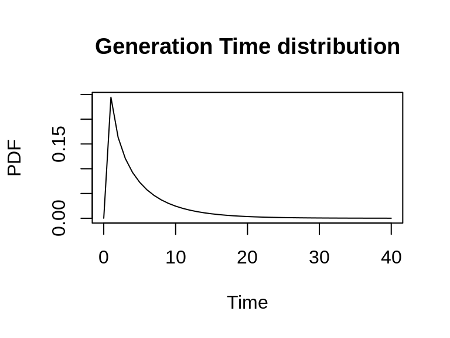

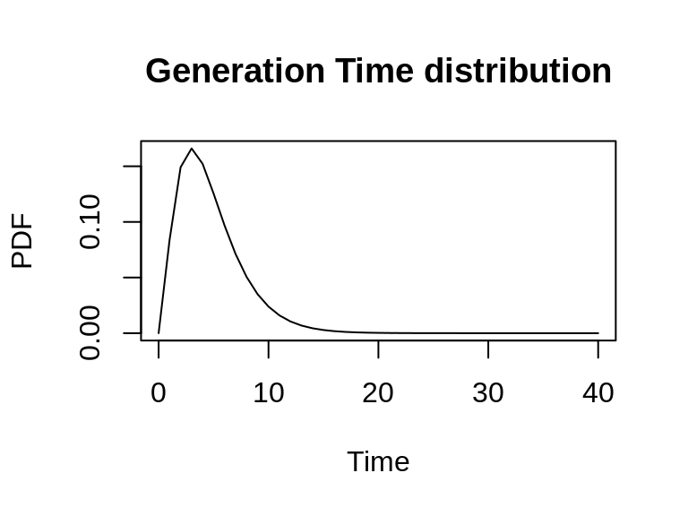

# R0 from exponential growth

We will use the COVID-19 data provided by the RKI as part of their COVID-19 Dashboard. The data contain the daily number of COVID-19 reports for each district and age-group. We will ignore the age-aspect in this analysis and will aggregate data to federal state level.

## Time frames of exponential growth

In order to estimate R0, we need to find adequate timeframes of exponential growth in the data.

We start with the following maximal admissible time span:

- **Start date:** *The day after the last day with zero cases*
- **End date:** *2020-03-20* – Reasoning: Interventions started somewhere between March 9 and March 16. We assume that they took some effect around March 13, and add five days for the incubation time and two days for testing and reporting to local authorities.

For our analysis we will use the R package [R0](https://cran.r-project.org/web/packages/R0/index.html), which is documented in `(Obadia et al. 2012)`.

A sensitivity analysis is performed with respect to different time spans contained in this maximal time span (incrementing or decrementing the start and end dates, respectively).

```r
find_timeframe <- setNames(lapply(list(gt_du_R0, gt_ni_R0), function (gt) {
  setNames(lapply(
    cases_list,
    function(cases) {
      first_date_with_cases <- as.integer(rev(which(cases == 0))[1] + 1)
      if (is.na(first_date_with_cases)) first_date_with_cases <- 1L
      begin_vector <- first_date_with_cases + 0:3
      end_vector <- which(names(cases) == "2020-03-20") + -3:0
      overlapping <- begin_vector >= end_vector
      R0::sensitivity.analysis(
        cases,
        GT = gt,
        begin = begin_vector,
        end = end_vector,
        est.method = "EG",
        sa.type = "time"
      )
    }
  ), case_vectors$Bundesland)
}), c("Du", "Nishiura"))
```

## Results

Entries with low `Rsquared` should not be trusted.

### Generation time distribution A

Only contains Bundeslaender for which `Rsquared` is above 0.85.

(Reminder: mean: 3.96, sd: 4.75)

| Bundesland | R0 | CI.lower | CI.upper | Rsquared |
| --- | --- | --- | --- | --- |
| Baden-Württemberg | 2.623392 | 2.556390 | 2.692647 | 0.9575905 |
| Bayern | 2.636439 | 2.575559 | 2.699102 | 0.9664909 |
| Berlin | 2.336785 | 2.218617 | 2.461227 | 0.8911401 |
| Brandenburg | 2.292195 | 2.072622 | 2.529683 | 0.8510590 |
| Hamburg | 2.640161 | 2.491425 | 2.798257 | 0.9560208 |
| Niedersachsen | 2.691925 | 2.570599 | 2.819774 | 0.9418437 |
| Nordrhein-Westfalen | 2.314958 | 2.271029 | 2.359876 | 0.9391144 |
| Rheinland-Pfalz | 3.269207 | 3.029367 | 3.530150 | 0.9448227 |
| Saarland | 2.332521 | 2.014009 | 2.688001 | 0.8614528 |
| Sachsen | 2.654256 | 2.466000 | 2.855288 | 0.9279571 |
| Schleswig-Holstein | 2.151504 | 1.917030 | 2.404390 | 0.9128308 |

### Generation time distribution B

Only contains Bundeslaender for which `Rsquared` is above 0.85.

(Reminder: mean: 4.7, sd: 2.9)

| Bundesland | R0 | CI.lower | CI.upper | Rsquared |
| --- | --- | --- | --- | --- |
| Baden-Württemberg | 3.057983 | 2.957704 | 3.162738 | 0.9575905 |
| Bayern | 3.077632 | 2.986284 | 3.172557 | 0.9664909 |
| Berlin | 2.636704 | 2.469093 | 2.817129 | 0.8911401 |
| Brandenburg | 2.573022 | 2.267267 | 2.918030 | 0.8510590 |
| Hamburg | 3.083246 | 2.861498 | 3.324578 | 0.9560208 |
| Niedersachsen | 3.161639 | 2.978880 | 3.357855 | 0.9418437 |
| Nordrhein-Westfalen | 2.605466 | 2.542977 | 2.669884 | 0.9391144 |
| Rheinland-Pfalz | 4.074948 | 3.687174 | 4.509117 | 0.9448227 |
| Saarland | 2.630591 | 2.187944 | 3.155676 | 0.8614528 |
| Sachsen | 3.104531 | 2.824127 | 3.412999 | 0.9279571 |
| Schleswig-Holstein | 2.375576 | 2.058930 | 2.734236 | 0.9128308 |

Please also use the plots for verifying that the time frame selected by our very heuristic choice seems adequate.

### Detailed results

Each Bundesland gets two results, one for each assumption on the generation time.

| Bundesland | Time.period | Begin.dates | End.dates | R | Growth.rate | Rsquared | CI.lower | CI.upper | GenerationTime |
| --- | --- | --- | --- | --- | --- | --- | --- | --- | --- |
| Baden-Württemberg | 24 | 2020-02-23 | 2020-03-18 | 2.623392 | 0.2537905 | 0.9575905 | 2.556390 | 2.692647 | A |
| Baden-Württemberg | 24 | 2020-02-23 | 2020-03-18 | 3.057983 | 0.2537905 | 0.9575905 | 2.957704 | 3.162738 | B |
| Bayern | 22 | 2020-02-27 | 2020-03-20 | 2.636439 | 0.2554970 | 0.9664909 | 2.575559 | 2.699102 | A |
| Bayern | 22 | 2020-02-27 | 2020-03-20 | 3.077632 | 0.2554970 | 0.9664909 | 2.986284 | 3.172557 | B |
| Berlin | 17 | 2020-03-03 | 2020-03-20 | 2.336785 | 0.2151563 | 0.8911401 | 2.218617 | 2.461227 | A |
| Berlin | 17 | 2020-03-03 | 2020-03-20 | 2.636704 | 0.2151563 | 0.8911401 | 2.469093 | 2.817129 | B |
| Brandenburg | 12 | 2020-03-08 | 2020-03-20 | 2.292195 | 0.2089402 | 0.8510590 | 2.072622 | 2.529683 | A |
| Brandenburg | 12 | 2020-03-08 | 2020-03-20 | 2.573022 | 0.2089402 | 0.8510590 | 2.267267 | 2.918030 | B |
| Bremen | 8 | 2020-03-12 | 2020-03-20 | 2.858028 | 0.2838303 | 0.5647807 | 2.243871 | 3.594360 | A |
| Bremen | 8 | 2020-03-12 | 2020-03-20 | 3.417266 | 0.2838303 | 0.5647807 | 2.504601 | 4.617801 | B |
| Hamburg | 16 | 2020-03-03 | 2020-03-19 | 2.640161 | 0.2559831 | 0.9560208 | 2.491425 | 2.798257 | A |
| Hamburg | 16 | 2020-03-03 | 2020-03-19 | 3.083246 | 0.2559831 | 0.9560208 | 2.861498 | 3.324578 | B |
| Hessen | 11 | 2020-03-09 | 2020-03-20 | 2.405878 | 0.2246761 | 0.8459784 | 2.269483 | 2.548625 | A |
| Hessen | 11 | 2020-03-09 | 2020-03-20 | 2.736395 | 0.2246761 | 0.8459784 | 2.540786 | 2.946151 | B |
| Mecklenburg-Vorpommern | 11 | 2020-03-08 | 2020-03-19 | 2.898742 | 0.2889069 | 0.7124435 | 2.459004 | 3.409023 | A |
| Mecklenburg-Vorpommern | 11 | 2020-03-08 | 2020-03-19 | 3.480844 | 0.2889069 | 0.7124435 | 2.813873 | 4.306053 | B |
| Niedersachsen | 18 | 2020-03-01 | 2020-03-19 | 2.691925 | 0.2627061 | 0.9418437 | 2.570599 | 2.819774 | A |
| Niedersachsen | 18 | 2020-03-01 | 2020-03-19 | 3.161639 | 0.2627061 | 0.9418437 | 2.978880 | 3.357855 | B |
| Nordrhein-Westfalen | 22 | 2020-02-26 | 2020-03-19 | 2.314958 | 0.2121206 | 0.9391144 | 2.271029 | 2.359876 | A |
| Nordrhein-Westfalen | 22 | 2020-02-26 | 2020-03-19 | 2.605466 | 0.2121206 | 0.9391144 | 2.542977 | 2.669884 | B |
| Rheinland-Pfalz | 14 | 2020-03-03 | 2020-03-17 | 3.269207 | 0.3333883 | 0.9448227 | 3.029367 | 3.530150 | A |
| Rheinland-Pfalz | 14 | 2020-03-03 | 2020-03-17 | 4.074948 | 0.3333883 | 0.9448227 | 3.687174 | 4.509117 | B |
| Saarland | 11 | 2020-03-08 | 2020-03-19 | 2.332521 | 0.2145642 | 0.8614528 | 2.014009 | 2.688001 | A |
| Saarland | 11 | 2020-03-08 | 2020-03-19 | 2.630591 | 0.2145642 | 0.8614528 | 2.187944 | 3.155676 | B |
| Sachsen | 12 | 2020-03-08 | 2020-03-20 | 2.654256 | 0.2578205 | 0.9279571 | 2.466000 | 2.855288 | A |
| Sachsen | 12 | 2020-03-08 | 2020-03-20 | 3.104531 | 0.2578205 | 0.9279571 | 2.824127 | 3.412999 | B |
| Sachsen-Anhalt | 4 | 2020-03-16 | 2020-03-20 | 1.672030 | 0.1160566 | 0.7595925 | 1.088924 | 2.348509 | A |
| Sachsen-Anhalt | 4 | 2020-03-16 | 2020-03-20 | 1.746098 | 0.1160566 | 0.7595925 | 1.088054 | 2.653533 | B |
| Schleswig-Holstein | 10 | 2020-03-10 | 2020-03-20 | 2.151504 | 0.1889432 | 0.9128308 | 1.917030 | 2.404390 | A |
| Schleswig-Holstein | 10 | 2020-03-10 | 2020-03-20 | 2.375576 | 0.1889432 | 0.9128308 | 2.058930 | 2.734236 | B |
| Thüringen | 9 | 2020-03-11 | 2020-03-20 | 3.155245 | 0.3200219 | 0.8321168 | 2.730702 | 3.636435 | A |
| Thüringen | 9 | 2020-03-11 | 2020-03-20 | 3.889293 | 0.3200219 | 0.8321168 | 3.220766 | 4.689401 | B |

### Plots

Case counts by date for each Bundesland.

**Light blue area** = Select time frame of exponential growth

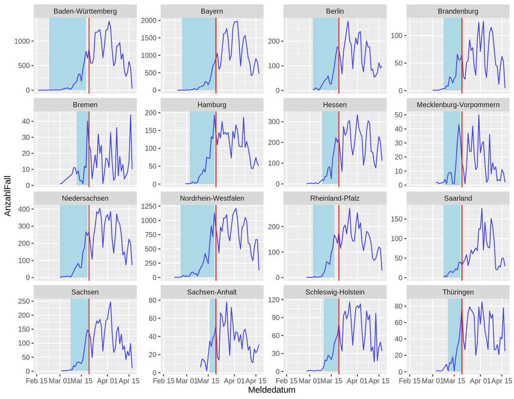

We see that for some Bundeslaender, notably Bremen, Sachsen-Anhalt, and Mecklenburg-Vorpommern, our analysis strategy fails.

# Time dependent R

## Using method “TD” of the R0 package

The function `R0::est.R0.TD` implements a method by `Wallinga and Teunis (2004)`. See package documentation for details. Unlike `EpiEstim::wallinga_teunis`, it provides some correction for cases not yet observed, leading to higher values of R0 close to the present days (approx. +0.5). This appears more realistic.

```r
time_dependent_R <- setNames(lapply(list(gt_du_R0, gt_ni_R0), function (gt) {
  setNames(lapply(
    cases_list,
    function(cases) {
      message("+")
      R0::est.R0.TD(
        cases,
        GT = gt,
        begin = which(names(cases) >= "2020-03-01")[1], # not used
        end = rev(which(names(cases) <= as.character(   # (only for plotting)
          max(covid19$Meldedatum) - 3)))[1],
        correct = TRUE # Does make a big difference (> +0.5 close to present)
      )
    }
  ), case_vectors$Bundesland)
}), c("Du", "Nishiura"))
```

## Using the EpiEstim package

The function `EpiEstim::estimate_R` in the R package [`EpiEstim`](https://cran.r-project.org/web/packages/EpiEstim/index.html), see `(Cori et al. 2013)` for an introduction, provides for a way to cope with some uncertainty regarding the serial interval distribution.

It might be good to extract some more information on variability of the serial intervals from literature. For now, we follow a naive approach.

The estimation uses sliding windows of seven days length.

```r
time_dependent_R_epiestim <- setNames(lapply(list(gt_du, gt_ni), function (gt) {
  setNames(lapply(
    cases_list,
    function(cases) {
      message("+")
      c(
        EpiEstim::estimate_R(
          cases,
          method = "uncertain_si",
          config = make_config(list(
            mean_si = gt["mean"], std_mean_si = 1,
            min_mean_si = gt["mean"] - 2, max_mean_si = gt["mean"] + 2,
            std_si = gt["sd"], std_std_si = 0.5,
            min_std_si = gt["sd"] - 1, max_std_si = gt["sd"] + 1,
            n1 = 100, n2 = 100
          ))
        ),
        date_map = list(as.Date(names(cases)))
      )
    }
  ), case_vectors$Bundesland)
}), c("Du", "Nishiura"))
```

The method involves the sampling of `n1` serial interval distributions. As an illustration, we plot the different serial interval distributions that were used in the estimation for Berlin (case A on the left, case B on the right).

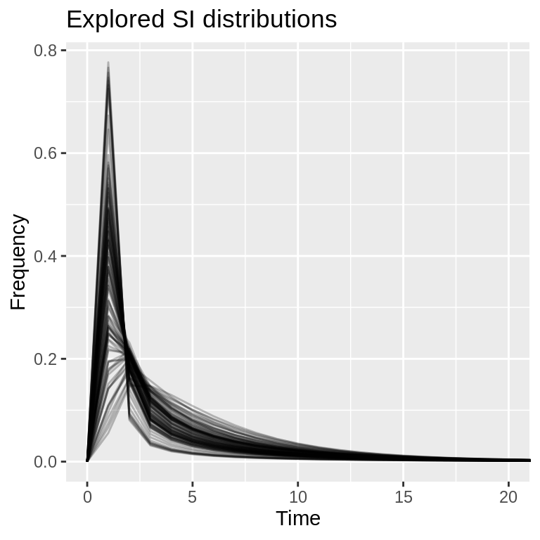

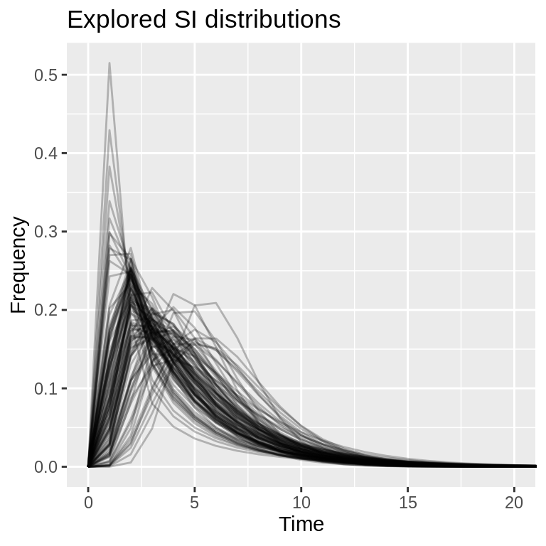

Note that the function still warns us (as of April 2 for five Bundeslaender):

> You’re estimating R too early in the epidemic to get the desired posterior CV.

Also warnings about serial interval distributions not summing to one appear, which is also due to too short a time span for which we have data, given the possibly long serial intervals (depending on the choice of parameters).

*Use results with care!*

## Results

Note that in the following plots, for EpiEstim, `Meldedatum` is the fourth day of the seven day long sliding window of the analyses.

Results are plotted until three days before the date of the most recent case reported in order to avoid problems related to reporting delays.

### Generation time distribution A

(Reminder: mean: 3.96, sd: 4.75)

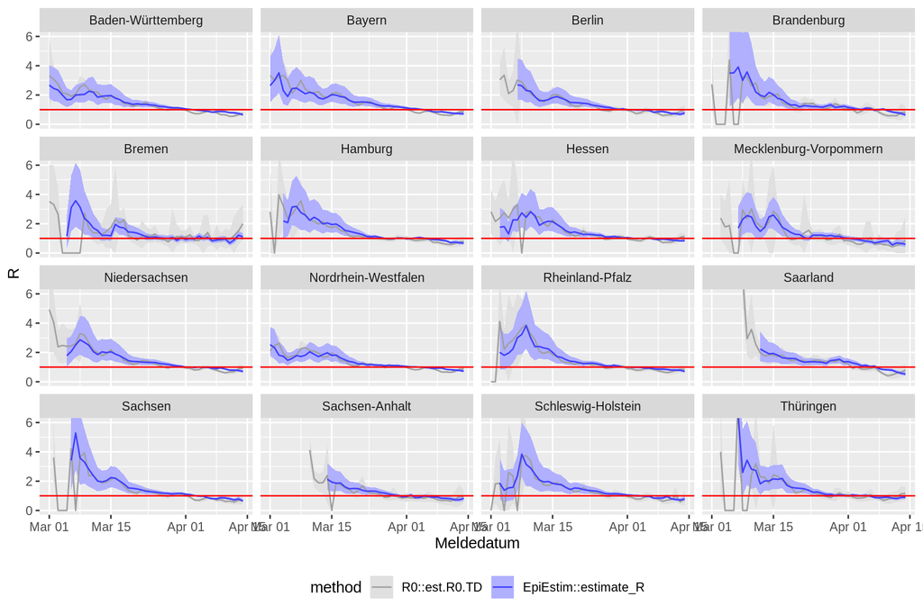

### Generation time distribution B

(Reminder: mean: 4.7, sd: 2.9)

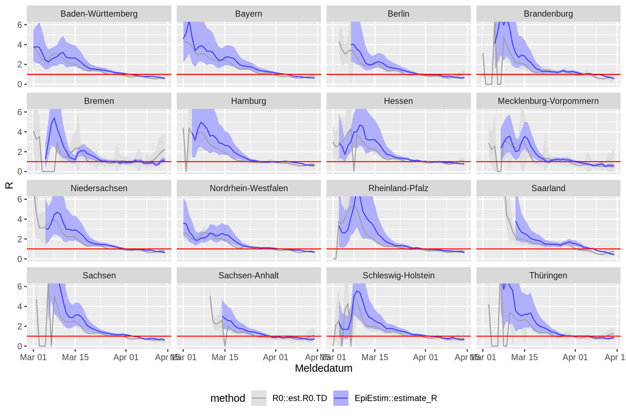

### Berlin A

(Reminder: mean: 3.96, sd: 4.75)

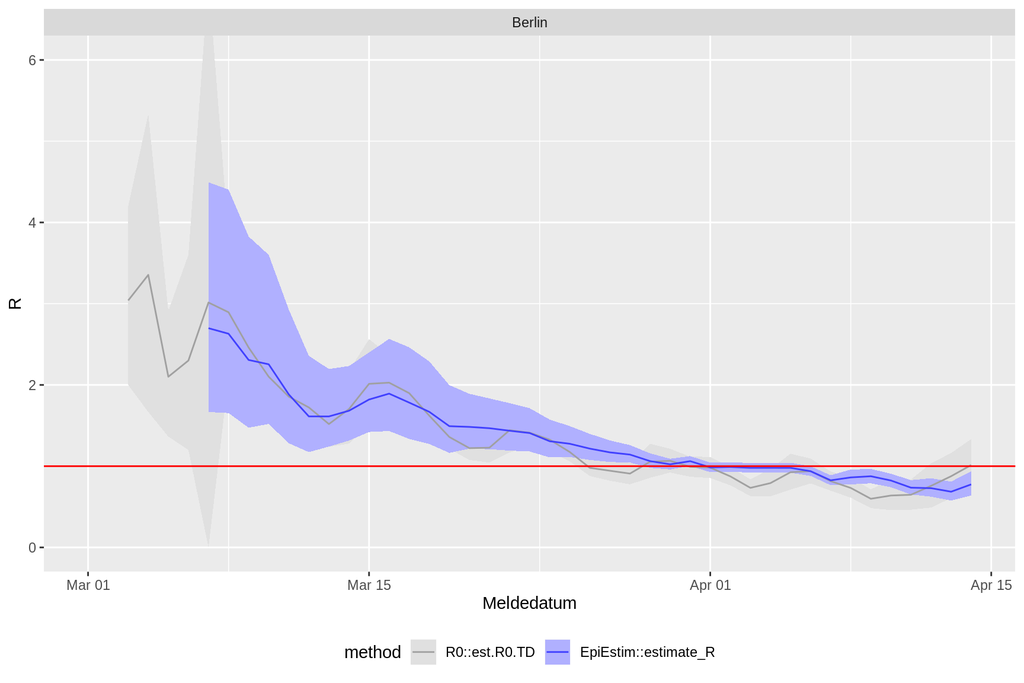

### Berlin B

(Reminder: mean: 4.7, sd: 2.9)

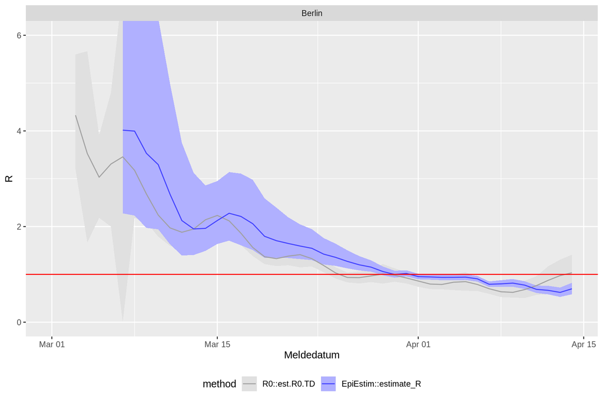

# Limitations

- Data is by date of notification, not by date of infection. The correction used for this is extremely rudimentary
- Under-reporting: Not everybody is tested, people can have COVID-19 with little or no symptoms
- Not enough data for time dependent method, especially with weekly sliding windows
- Limited knowledge on serial interval distribution; problems related to pre-symptomatic infectiousness
- The “discussion” section in `(Cori et al 2013)` is a good read!
- …

# Bibliography

Du Z, Xu X, Wu Y, Wang L, Cowling BJ, Ancel Meyers L. *Serial interval of COVID-19 among publicly reported confirmed cases*. Emerg Infect Dis. Jun 2020, https://doi.org/10.3201/eid2606.200357

Cori, A., Ferguson, N., Fraser, Chr. & Cauchemez, S. *A New Framework and Software to Estimate Time-Varying Reproduction Numbers During Epidemics*. American Journal of Epidemiology, Volume 178, Issue 9, 1 November 2013, 1505–1512, https://doi.org/10.1093/aje/kwt133

Nishiura H, Linton NM, Akhmetzhanov AR. Serial interval of novel coronavirus (COVID-19) infections. Int J Infect Dis, 4 March 2020, 93, 284-286, https://doi.org/10.1016/j.ijid.2020.02.060

Obadia, T., Haneef, R. & Boëlle, P. *The R0 package: a toolbox to estimate reproduction numbers for epidemic outbreaks*. BMC Med Inform Decis Mak 12, 147 (2012). https://doi.org/10.1186/1472-6947-12-147

Wallinga, J., Teunis, P. *Different Epidemic Curves for Severe Acute Respiratory Syndrome Reveal Similar Impacts of Control Measures*. American Journal of Epidemiology, Volume 160, Issue 6, 15 September 2004, 509–516, https://doi.org/10.1093/aje/kwh255